# Health Impact Assessment of Affordable Housing Development in Connecticut

```r
library(tidyverse)
library(sf)
library(here)
library(tidycensus)
library(daymetr)
```

```r
# read in PM2.5 daily average by census tract from EPA FAQSD
pm_tract <- read.delim(gzfile("2019_pm25_daily_average.txt.gz"), sep = ",") %>%
## include only Connecticut tracts - FIPS starting with 9
  filter(str_detect(`FIPS`, "^9")) %>%
## include only index date - July 4, 2019
  filter(`Date` == "2019/07/04") %>%
## format FIPS to match GEOID format used by tidycensus get_acs
  mutate(GEOID = str_pad(FIPS, 11, side = "left", pad = "0"))

# read in ozone daily 8-hour maximum by census tract from EPA FAQSD
o3_tract <- read.delim(gzfile("2019_ozone_daily_8hour_maximum.txt.gz"), sep = ",") %>%
## include only Connecticut tracts - FIPS starting with 9
  filter(str_detect(`FIPS`, "^9")) %>%
## include only index date - July 4, 2019
  filter(`Date` == "2019/07/04") %>%
## format FIPS to match GEOID format used by tidycensus get_acs
  mutate(GEOID = str_pad(FIPS, 11, side = "left", pad = "0"))
```

```r
# read housing data from CT Open Data
housing_town <- read.csv("Affordable_Housing_by_Town_2011-2022.csv") %>%
  filter(`Year` == 2019) %>%
  mutate(`At least 10%?` = cut(`Percent.Affordable`, breaks = c(0,9.99999,100),
  labels = c("No", "Yes"))) %>%
  rename("TOWN_NAME" = "Town") %>%
  mutate(`Units Needed` = (1-(`Percent.Affordable`/10))*`X2010.Census.Units`*(1/9))

# set units needed to 0 for towns already at or above 10% threshold
housing_town$`Units Needed`[housing_town$`At least 10%` == "Yes"] = 0
```

```r
# read county-level ischemic heart disease mortality rates from CDC WONDER
ischemic <- read.delim("Underlying Cause of Death, 2018-2021, Single Race.txt", sep = "\t")[1:8,-1] %>%
  mutate(`CNTY_NAME` = substr(`County`, 1, nchar(`County`)-11), .before = 2)
```

```r
# list of ACS variable names for reference
vars <- load_variables(year = 2019, dataset = "acs5", cache = TRUE)
```

```r
options(tigris_use_cache = TRUE)

# get CT census tract polygon
ct_tracts <- get_acs(state = "CT", geography = "tract", variables = "B17013_002", geometry = TRUE, year = 2019) %>%
## join PM2.5 data
  left_join(., pm_tract, by = "GEOID") %>%
## join ozone data
  left_join(., o3_tract, by = "GEOID")
# read CT town lines
town_lines <- st_read("CT Town Lines/Town_Lines.shp")
# read CT town polygon
town_polygon <- st_read("CT Vicinity Town Polygon/CT_Vicinity_Town_Polygon.shp") %>%
  filter(STATE_COD == "CT") %>%
# join housing data by town - using inner over left join to exclude area of Long Island Sound
  inner_join(., housing_town, by = "TOWN_NAME")
head(town_polygon)
```

|  | OBJECTID | LAND_CLASS | CT_LEGEND | STATE_COD | STATE_NAME | CNTY_FIELD | CNTY_COD | CNTY_NAME | TOWN_FIELD | TOWN_NAME | LABEL_FLAG | MAP_LABEL | CT_LABEL_Y | CT_LABEL_N | SHAPE_Leng | SHAPE_Area | Year | Town.Code | X2010.Census.Units | Government.Assisted | Tenant.Rental.Assistance | Single.Family.CHFA..USDA.Mortgages | Deed.Restricted.Units | Total.Assisted.Units | Percent.Affordable | At least 10%? | Units Needed | geometry |
| --- | --- | --- | --- | --- | --- | --- | --- | --- | --- | --- | --- | --- | --- | --- | --- | --- | --- | --- | --- | --- | --- | --- | --- | --- | --- | --- | --- | --- |
| 1 | 23 | Land | Connecticut | CT | Connecticut | CNTY_COD | 3 | Litchfield | TOWN_NO | Salisbury | True | Salisbury | Salisbury | NA | 0.5966662696 | 1.693281e-02 | 2019 | 122 | 2593 | 24 | 2 | 2 | 14 | 42 | 1.62 | No | 241.43711 |  |
| 2 | 26 | Land | Connecticut | CT | Connecticut | CNTY_COD | 3 | Litchfield | TOWN_NO | North Canaan | True | North Canaan | North Canaan | NA | 0.3304418675 | 5.496483e-03 | 2019 | 100 | 1587 | 148 | 1 | 14 | 0 | 163 | 10.27 | Yes | 0.00000 |  |
| 3 | 27 | Land | Connecticut | CT | Connecticut | CNTY_COD | 3 | Litchfield | TOWN_NO | Norfolk | True | Norfolk | Norfolk | NA | 0.4699487948 | 1.304085e-02 | 2019 | 98 | 967 | 21 | 2 | 4 | 0 | 27 | 2.79 | No | 77.46744 |  |
| 4 | 28 | Land | Connecticut | CT | Connecticut | CNTY_COD | 3 | Litchfield | TOWN_NO | Colebrook | True | Colebrook | Colebrook | NA | 0.4017260009 | 9.255303e-03 | 2019 | 29 | 722 | 0 | 1 | 6 | 1 | 8 | 1.11 | No | 71.31756 |  |
| 5 | 29 | Land | Connecticut | CT | Connecticut | CNTY_COD | 2 | Hartford | TOWN_NO | Hartland | True | Hartland | Hartland | NA | 0.4305969828 | 9.646552e-03 | 2019 | 65 | 856 | 2 | 0 | 4 | 0 | 6 | 0.70 | No | 88.45333 |  |
| 6 | 192 | Land | Connecticut | CT | Connecticut | CNTY_COD | 5 | New Haven | TOWN_NO | Branford | False | NA | NA | NA | 0.0005285453 | 1.928654e-08 | 2019 | 14 | 13972 | 233 | 60 | 176 | 0 | 469 | 3.36 | No | 1030.82311 |  |

```r
# using spreadsheet from 2010 census tract to town conversion tool from CT Data Collaborative: https://tract2town.ctdata.org/
tract_town <- read.csv("Census_Tracts_with_Town_Names__2010_.csv") %>%
## join families by tract to towns by tract
  mutate(GEOID = str_pad(GEOID, 11, side = "left", pad = "0")) %>%
  right_join(ct_tracts, by = "GEOID") %>%
## clean rows - delete undefined township, for now keeping rows with no exposure data (East Lyme, Wolcott)
  filter(`Town` != "County subdivisions not defined")

## clean rows - assign tracts with multiple towns and 0 families to one town
tract_town$Town[tract_town$Town == "East Granby, Windsor Locks, Suffield"] <- "East Granby"
tract_town$Town[tract_town$Town == "Groton, Ledyard"] <- "Groton"
tract_town$Town[tract_town$Town == "Norwalk, Darien, Greenwich, Stamford, Westport"] <- "Norwalk"

## assigning all 20 families in tract to Union, this is the only tract containing Union
tract_town$Town[tract_town$Town == "Stafford, Union"] <- "Union"

## splitting "Canaan, Norfolk" estimate among both since both are only found in this tract
tract_town <- tract_town %>% bind_rows(slice(., which(tract_town$Town == "Canaan, Norfolk")))
tract_town$Town[tract_town$Town == "Canaan, Norfolk"] <- "Canaan"
tract_town$Town[nrow(tract_town)] <- "Norfolk"
tract_town$estimate[tract_town$Town == "Canaan"] <- floor(tract_town$estimate[642]/2)
tract_town$estimate[tract_town$Town == "Norfolk"] <- ceiling(tract_town$estimate[833]/2)

head(tract_town)
```

|  | FID | STATEFP10 | COUNTYFP10 | TRACTCE10 | NAME10 | NAMELSAD10 | MTFCC10 | FUNCSTAT10 | ALAND10 | AWATER10 | INTPTLAT10 | INTPTLON10 | GEOID | Full_GEOID | Town | NAME | variable | estimate | moe | Date.x | FIPS.x | Longitude.x | Latitude.x | pm25_daily_average.ug.m3. | pm25_daily_average_stderr.ug.m3. | Date.y | FIPS.y | Longitude.y | Latitude.y | … |
| --- | --- | --- | --- | --- | --- | --- | --- | --- | --- | --- | --- | --- | --- | --- | --- | --- | --- | --- | --- | --- | --- | --- | --- | --- | --- | --- | --- | --- | --- | --- |
| 1 | 0 | 9 | 1 | 30300 | 303 | Census Tract 303 | G5020 | S | 8268946 | 5919424 | 41.05635 | -73.47365 | 09001030300 | 1400000US09001030300 | Darien | Census Tract 303, Fairfield County, Connecticut | B17013_002 | 0 | 12 | 2019/07/04 | 9001030300 | -73.47020 | 41.06065 | 22.064 | 9.3419 | 2019/07/04 | 9001030300 | -73.47020 | 41.06065 | … |
| 2 | 1 | 9 | 1 | 35300 | 353 | Census Tract 353 | G5020 | S | 13442741 | 46233 | 41.12153 | -73.47843 | 09001035300 | 1400000US09001035300 | New Canaan | Census Tract 353, Fairfield County, Connecticut | B17013_002 | 17 | 19 | 2019/07/04 | 9001035300 | -73.50094 | 41.12916 | 21.808 | 9.2616 | 2019/07/04 | 9001035300 | -73.50094 | 41.12916 | … |
| 3 | 2 | 9 | 1 | 11000 | 110 | Census Tract 110 | G5020 | S | 4449326 | 3865378 | 41.01226 | -73.57670 | 09001011000 | 1400000US09001011000 | Greenwich | Census Tract 110, Fairfield County, Connecticut | B17013_002 | 65 | 52 | 2019/07/04 | 9001011000 | -73.56726 | 41.02579 | 22.614 | 9.6063 | 2019/07/04 | 9001011000 | -73.56726 | 41.02579 | … |
| 4 | 3 | 9 | 1 | 30100 | 301 | Census Tract 301 | G5020 | S | 11024824 | 27898 | 41.10066 | -73.48820 | 09001030100 | 1400000US09001030100 | Darien | Census Tract 301, Fairfield County, Connecticut | B17013_002 | 10 | 16 | 2019/07/04 | 9001030100 | -73.48699 | 41.09969 | 21.857 | 9.5290 | 2019/07/04 | 9001030100 | -73.48699 | 41.09969 | … |
| 5 | 4 | 9 | 1 | 30200 | 302 | Census Tract 302 | G5020 | S | 4579450 | 45867 | 41.08550 | -73.46446 | 09001030200 | 1400000US09001030200 | Darien | Census Tract 302, Fairfield County, Connecticut | B17013_002 | 22 | 25 | 2019/07/04 | 9001030200 | -73.46511 | 41.08408 | 21.919 | 9.4223 | 2019/07/04 | 9001030200 | -73.46511 | 41.08408 | … |
| 6 | 5 | 9 | 1 | 30400 | 304 | Census Tract 304 | G5020 | S | 3552882 | 0 | 41.06700 | -73.48994 | 09001030400 | 1400000US09001030400 | Darien | Census Tract 304, Fairfield County, Connecticut | B17013_002 | 42 | 33 | 2019/07/04 | 9001030400 | -73.48998 | 41.06699 | 22.101 | 9.4473 | 2019/07/04 | 9001030400 | -73.48998 | 41.06699 | … |

```r
# summarize mean PM2.5 and standard deviation of tract-level estimates by town
pm_town <- tract_town %>%
  rename(`TOWN_NAME` = `Town`) %>%
  group_by(`TOWN_NAME`) %>%
  summarize(`Average PM2.5 (ug/m3)` = mean(`pm25_daily_average.ug.m3.`, na.rm = TRUE), `Standard Deviation (ug/m3)` = sd(`pm25_daily_average.ug.m3.`, na.rm = TRUE), `Min` = min(`pm25_daily_average.ug.m3.`, na.rm = TRUE), `Max` = max(`pm25_daily_average.ug.m3.`, na.rm = TRUE))

head(pm_town)
```

| TOWN_NAME | Average PM2.5 (ug/m3) | Standard Deviation (ug/m3) | Min | Max |
| --- | --- | --- | --- | --- |
| Andover | 16.05700 | NA | 16.057 | 16.057 |
| Ansonia | 18.79125 | 0.19802083 | 18.653 | 19.085 |
| Ashford | 15.34100 | NA | 15.341 | 15.341 |
| Avon | 16.90775 | 0.09952345 | 16.797 | 17.039 |
| Barkhamsted | 16.05200 | NA | 16.052 | 16.052 |
| Beacon Falls | 18.41100 | NA | 18.411 | 18.411 |

```r
# summarize mean and standard deviation of tract-level ozone estimates by town
o3_town <- tract_town %>%
  rename(`TOWN_NAME` = `Town`) %>%
  group_by(`TOWN_NAME`) %>%
  summarize(`Average O3 (ppb)` = mean(`ozone_daily_8hour_maximum.ppb.`, na.rm = TRUE), `Standard Deviation (ppb)` = sd(`ozone_daily_8hour_maximum.ppb.`, na.rm = TRUE), `Min O3` = min(`ozone_daily_8hour_maximum.ppb.`, na.rm = TRUE), `Max O3` = max(`ozone_daily_8hour_maximum.ppb.`, na.rm = TRUE))

head(o3_town)
```

| TOWN_NAME | Average O3 (ppb) | Standard Deviation (ppb) | Min O3 | Max O3 |
| --- | --- | --- | --- | --- |
| Andover | 55.71800 | NA | 55.718 | 55.718 |
| Ansonia | 70.01600 | 0.2652332 | 69.755 | 70.370 |
| Ashford | 48.45100 | NA | 48.451 | 48.451 |
| Avon | 59.25525 | 0.3237266 | 58.937 | 59.646 |
| Barkhamsted | 54.33200 | NA | 54.332 | 54.332 |
| Beacon Falls | 67.24600 | NA | 67.246 | 67.246 |

```r
# join to town polygon
pm_town_sf <- town_polygon %>%
  left_join(pm_town, by = "TOWN_NAME")

o3_town_sf <- town_polygon %>%
  left_join(o3_town, by = "TOWN_NAME")

# summarize families by town and join housing by town
pop_town <- tract_town %>%
  group_by(`Town`) %>%
  summarize(`Families Pre` = sum(`estimate`)) %>%
  rename(`TOWN_NAME` = `Town`) %>%
  full_join(housing_town, by = "TOWN_NAME")

head(pop_town)
```

| TOWN_NAME | Families Pre | Year | Town.Code | X2010.Census.Units | Government.Assisted | Tenant.Rental.Assistance | Single.Family.CHFA..USDA.Mortgages | Deed.Restricted.Units | Total.Assisted.Units | Percent.Affordable | At least 10%? | Units Needed |
| --- | --- | --- | --- | --- | --- | --- | --- | --- | --- | --- | --- | --- |
| Andover | 0 | 2019 | 1 | 1317 | 18 | 1 | 29 | 0 | 48 | 3.64 | No | 93.0680 |
| Ansonia | 589 | 2019 | 2 | 8148 | 349 | 752 | 140 | 9 | 1250 | 15.34 | Yes | 0.0000 |
| Ashford | 73 | 2019 | 3 | 1903 | 32 | 0 | 35 | 0 | 67 | 3.52 | No | 137.0160 |
| Avon | 160 | 2019 | 4 | 7389 | 244 | 13 | 43 | 0 | 300 | 4.06 | No | 487.6740 |
| Barkhamsted | 58 | 2019 | 5 | 1589 | 0 | 6 | 20 | 0 | 26 | 1.64 | No | 147.6004 |
| Beacon Falls | 121 | 2019 | 6 | 2509 | 0 | 3 | 46 | 0 | 49 | 1.95 | No | 224.4161 |

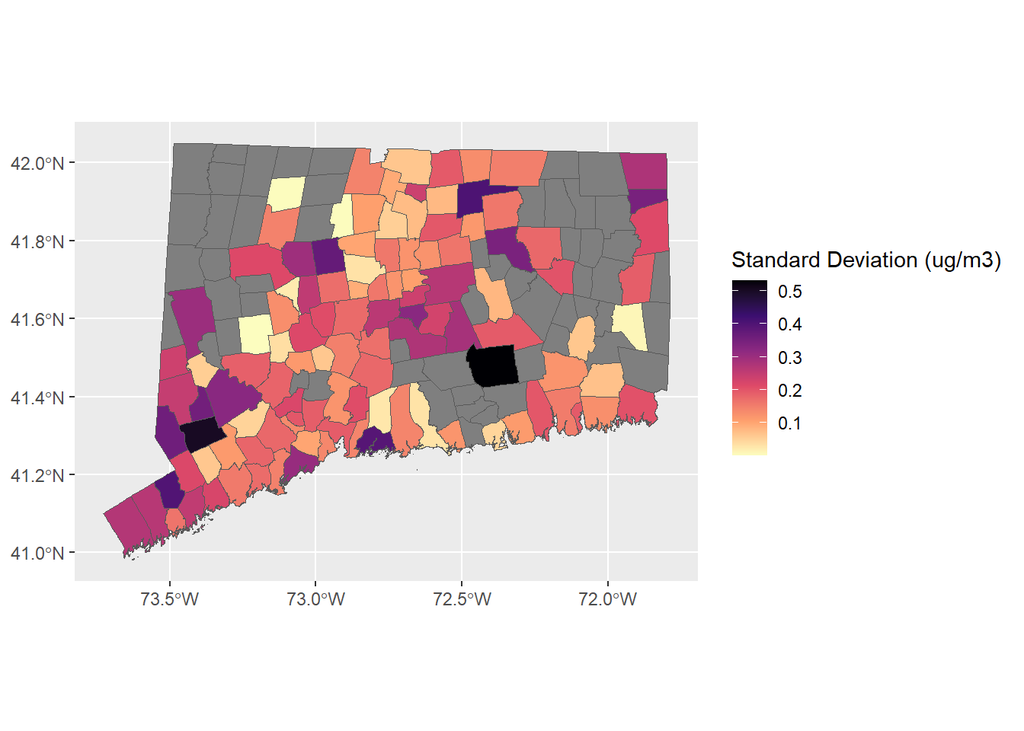

```r
# map PM2.5 standard deviation by town
ggplot() + geom_sf(data = pm_town_sf, aes(fill = `Standard Deviation (ug/m3)`)) +
  scale_fill_viridis_c(option = "magma", direction = -1)
```

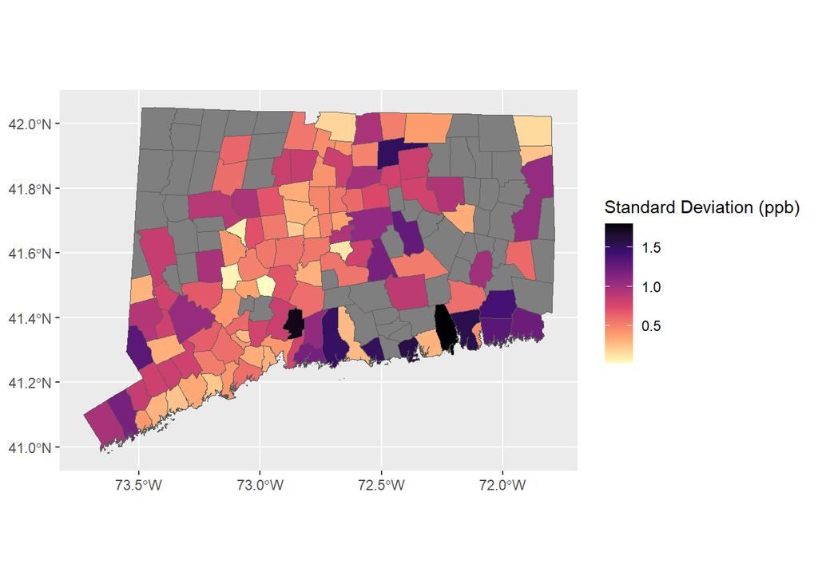

```r
# map ozone standard deviation by town
ggplot() + geom_sf(data = o3_town_sf, aes(fill = `Standard Deviation (ppb)`)) +
  scale_fill_viridis_c(option = "magma", direction = -1)
```

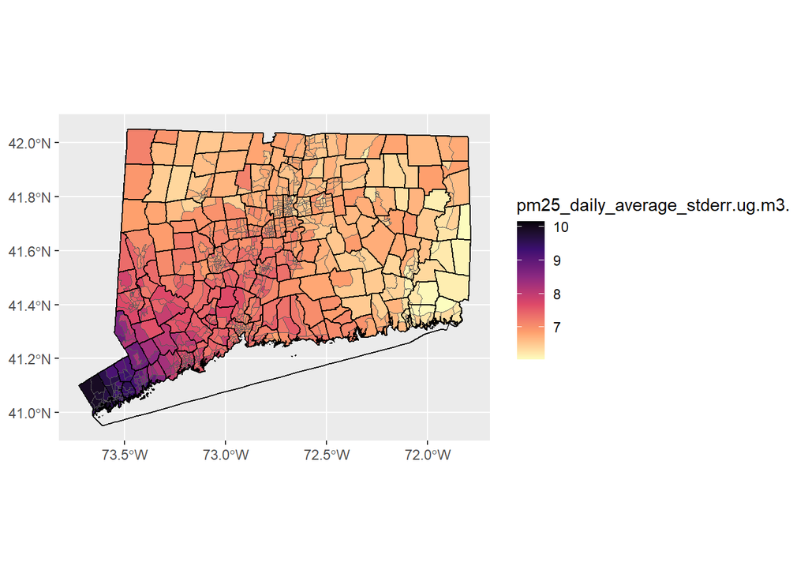

```r
# map PM2.5 standard error by census tract with town lines
ggplot() + geom_sf(data = ct_tracts, aes(fill = pm25_daily_average_stderr.ug.m3.)) +
  scale_fill_viridis_c(option = "magma", direction = -1) + geom_sf(data = town_lines)
```

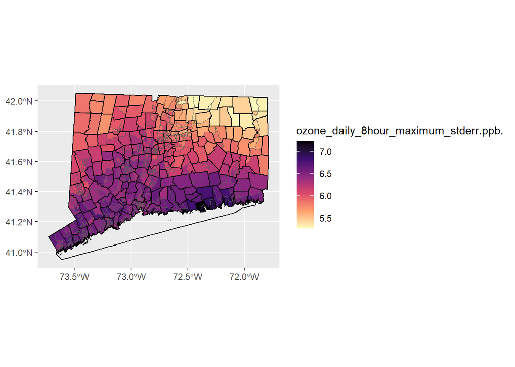

```r
# map ozone standard error by census tract with town lines
ggplot() + geom_sf(data = ct_tracts, aes(fill = ozone_daily_8hour_maximum_stderr.ppb.)) +
  scale_fill_viridis_c(option = "magma", direction = -1) + geom_sf(data = town_lines)
```

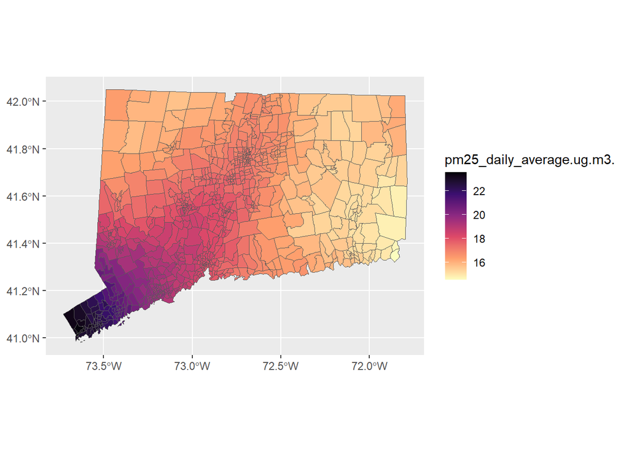

```r
# map PM2.5 by census tract without town lines
ggplot() + geom_sf(data = ct_tracts, aes(fill = pm25_daily_average.ug.m3.)) +
  scale_fill_viridis_c(option = "magma", direction = -1)
```

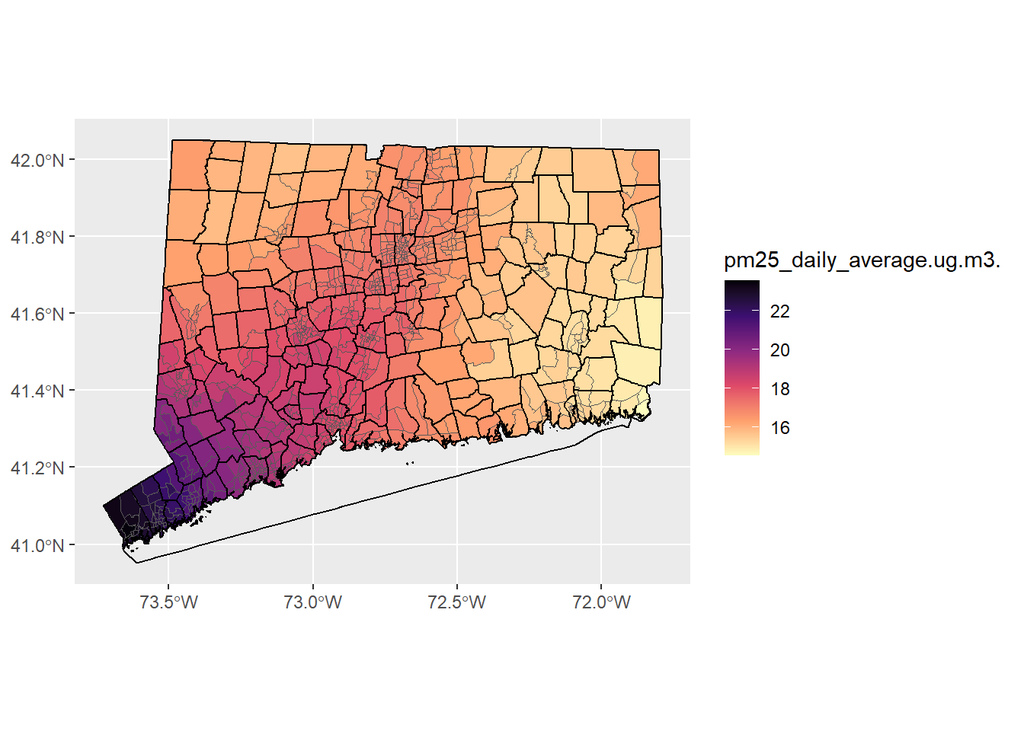

```r
# map PM2.5 by census tract with town lines
ggplot() + geom_sf(data = ct_tracts, aes(fill = pm25_daily_average.ug.m3.)) +
  scale_fill_viridis_c(option = "magma", direction = -1) + geom_sf(data = town_lines)
```

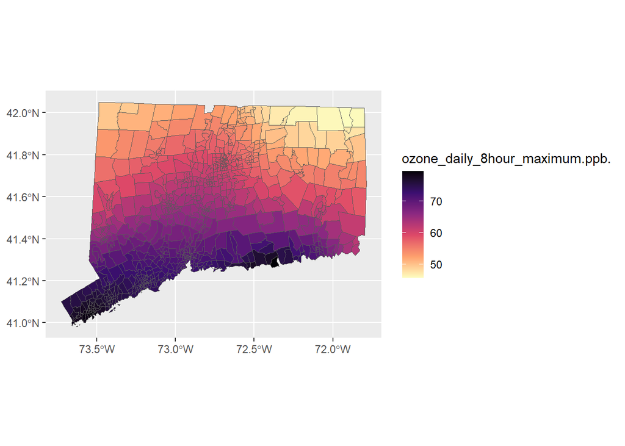

```r
# map O3 by census tract without town lines
ggplot() + geom_sf(data = ct_tracts, aes(fill = ozone_daily_8hour_maximum.ppb.)) +
  scale_fill_viridis_c(option = "magma", direction = -1)
```

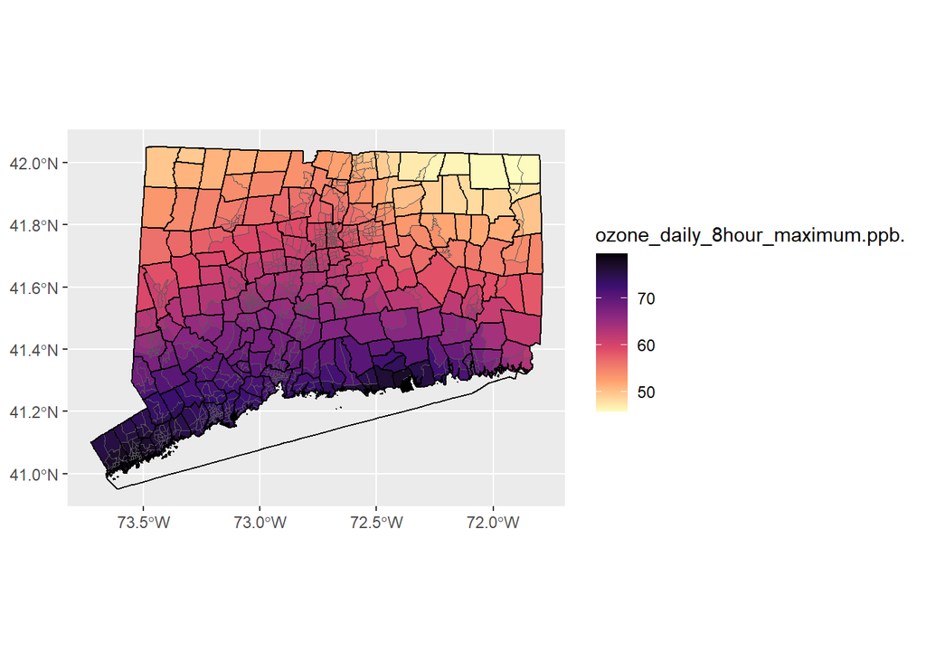

```r
# map O3 by census tract with town lines
ggplot() + geom_sf(data = ct_tracts, aes(fill = ozone_daily_8hour_maximum.ppb.)) +
  scale_fill_viridis_c(option = "magma", direction = -1) + geom_sf(data = town_lines)
```

```r
# map temperature by census tract
```

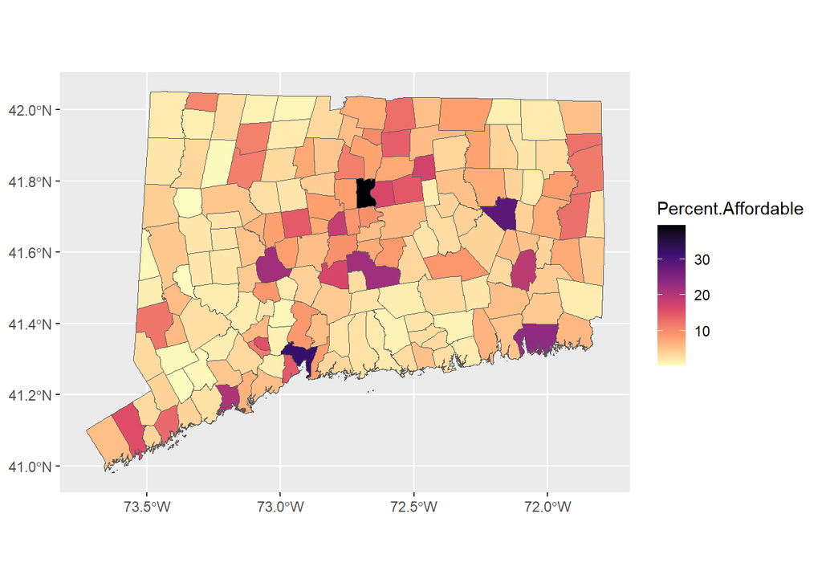

```r
# map percent of affordable housing units by town
ggplot() + geom_sf(data = town_polygon, aes(fill = `Percent.Affordable`)) +
  scale_fill_viridis_c(option = "magma", direction = -1)
```

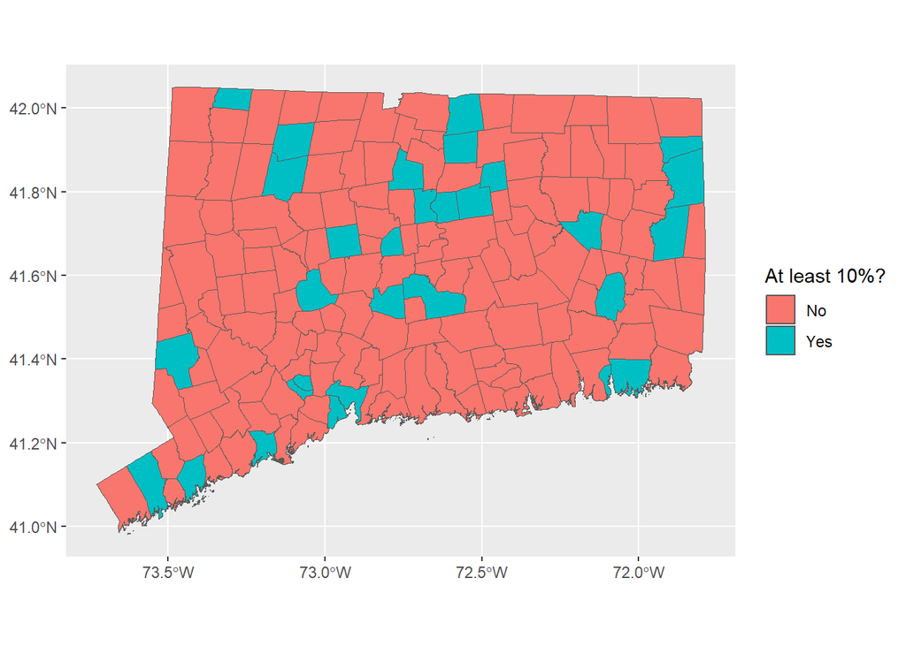

```r
# map 8-30g exemptions by town
ggplot() + geom_sf(data = town_polygon, aes(fill = `At least 10%?`))
```

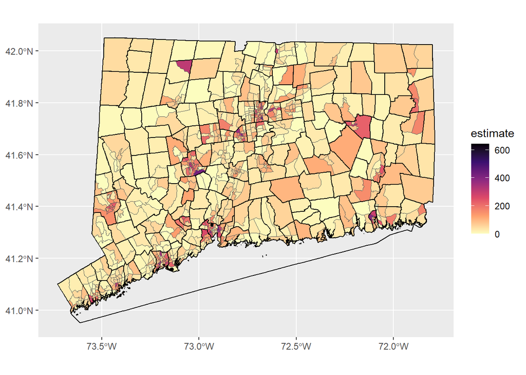

```r
# map families below poverty level by census tract
ggplot() + geom_sf(data = ct_tracts, aes(fill = estimate)) +
  scale_fill_viridis_c(option = "magma", direction = -1) + geom_sf(data = town_lines)
```

```r
# map low-income population by census tract

# map rent burdened population by census tract
```

```r
# map baseline incidence of heart disease mortality by census tract
```

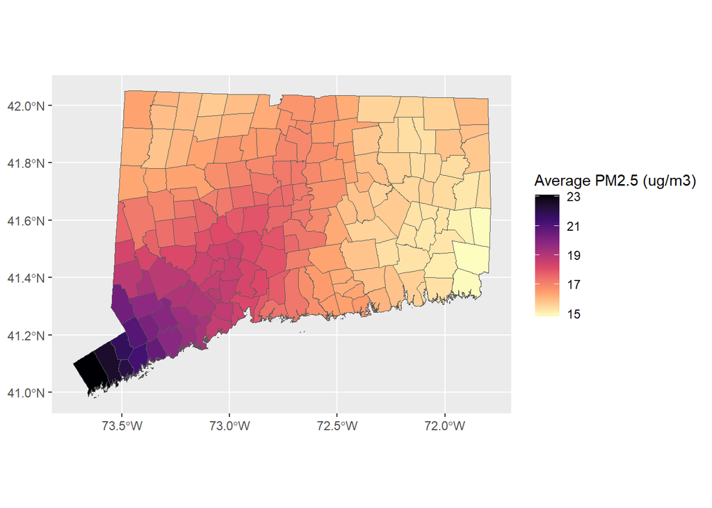

```r
# map PM2.5 by town
ggplot() + geom_sf(data = pm_town_sf, aes(fill = `Average PM2.5 (ug/m3)`)) +
  scale_fill_viridis_c(option = "magma", direction = -1)
```

```r
# simulate random movement into new units
pop_town <- pop_town %>%
  mutate(`Moved In` = rpois(nrow(.), round(`Units Needed`, 0)))

# list towns pre-move by family (one row per family) and draw random sample (moving out) equal to number of families moved in
moved_out_from <- rep(pop_town$TOWN_NAME, times = pop_town$`Families Pre`) %>%
  sample(sum(pop_town$`Moved In`), replace = FALSE)

head(moved_out_from)
```

```
## [1] "Bridgeport" "East Haven" "Killingly"  "Ledyard"    "Hartford"
## [6] "Windsor"
```

```r
# summarize families moved out by town and join pop_town
pop_town_moved <- moved_out_from %>%
  data.frame() %>%
  rename(`TOWN_NAME` = 1) %>%
  group_by(`TOWN_NAME`) %>%
  summarize(`Moved Out` = n()) %>%
  full_join(pop_town, by = "TOWN_NAME")

# replace NA's for number moved out with 0's (towns not drawn in sample of families)
pop_town_moved$`Moved Out`[is.na(pop_town_moved$`Moved Out`)] <- 0

# subtract families moved out and add families moved in to initial estimate for final estimate
pop_town_moved <- pop_town_moved %>%
  mutate(`Families Post` = `Families Pre` + `Moved In` - `Moved Out`)

#join to town polygon
towns_moved <- town_polygon %>%
  left_join(pop_town_moved, by = "TOWN_NAME")

head(towns_moved)
```

|  | OBJECTID | LAND_CLASS | CT_LEGEND | STATE_COD | STATE_NAME | CNTY_FIELD | CNTY_COD | CNTY_NAME | TOWN_FIELD | TOWN_NAME | LABEL_FLAG | MAP_LABEL | CT_LABEL_Y | CT_LABEL_N | SHAPE_Leng | SHAPE_Area | Year.x | Town.Code.x | X2010.Census.Units.x | Government.Assisted.x | Tenant.Rental.Assistance.x | Single.Family.CHFA..USDA.Mortgages.x | Deed.Restricted.Units.x | Total.Assisted.Units.x | Percent.Affordable.x | At least 10%?.x | Units Needed.x | Moved Out | Families Pre | … |
| --- | --- | --- | --- | --- | --- | --- | --- | --- | --- | --- | --- | --- | --- | --- | --- | --- | --- | --- | --- | --- | --- | --- | --- | --- | --- | --- | --- | --- | --- | --- |
| 1 | 23 | Land | Connecticut | CT | Connecticut | CNTY_COD | 3 | Litchfield | TOWN_NO | Salisbury | True | Salisbury | Salisbury | NA | 0.5966662696 | 1.693281e-02 | 2019 | 122 | 2593 | 24 | 2 | 2 | 14 | 42 | 1.62 | No | 241.43711 | 38 | 46 | … |
| 2 | 26 | Land | Connecticut | CT | Connecticut | CNTY_COD | 3 | Litchfield | TOWN_NO | North Canaan | True | North Canaan | North Canaan | NA | 0.3304418675 | 5.496483e-03 | 2019 | 100 | 1587 | 148 | 1 | 14 | 0 | 163 | 10.27 | Yes | 0.00000 | 34 | 38 | … |
| 3 | 27 | Land | Connecticut | CT | Connecticut | CNTY_COD | 3 | Litchfield | TOWN_NO | Norfolk | True | Norfolk | Norfolk | NA | 0.4699487948 | 1.304085e-02 | 2019 | 98 | 967 | 21 | 2 | 4 | 0 | 27 | 2.79 | No | 77.46744 | 13 | 15 | … |
| 4 | 28 | Land | Connecticut | CT | Connecticut | CNTY_COD | 3 | Litchfield | TOWN_NO | Colebrook | True | Colebrook | Colebrook | NA | 0.4017260009 | 9.255303e-03 | 2019 | 29 | 722 | 0 | 1 | 6 | 1 | 8 | 1.11 | No | 71.31756 | 3 | 5 | … |
| 5 | 29 | Land | Connecticut | CT | Connecticut | CNTY_COD | 2 | Hartford | TOWN_NO | Hartland | True | Hartland | Hartland | NA | 0.4305969828 | 9.646552e-03 | 2019 | 65 | 856 | 2 | 0 | 4 | 0 | 6 | 0.70 | No | 88.45333 | 6 | 7 | … |
| 6 | 192 | Land | Connecticut | CT | Connecticut | CNTY_COD | 5 | New Haven | TOWN_NO | Branford | False | NA | NA | NA | 0.0005285453 | 1.928654e-08 | 2019 | 14 | 13972 | 233 | 60 | 176 | 0 | 469 | 3.36 | No | 1030.82311 | 297 | 398 | … |

```r
# check that total families moved in and moved out match - value will vary with each simulation
sum(pop_town_moved$`Moved Out`)
```

```
## [1] 46712
```

```r
sum(pop_town_moved$`Moved In`)
```

```
## [1] 46712
```

```r
# check that total families pre and post match - value should match Census estimate
sum(pop_town_moved$`Families Pre`)
```

```
## [1] 61049
```

```r
sum(pop_town_moved$`Families Post`)
```

```
## [1] 61049
```

```r
sum(ct_tracts$estimate)
```

```
## [1] 61049
```

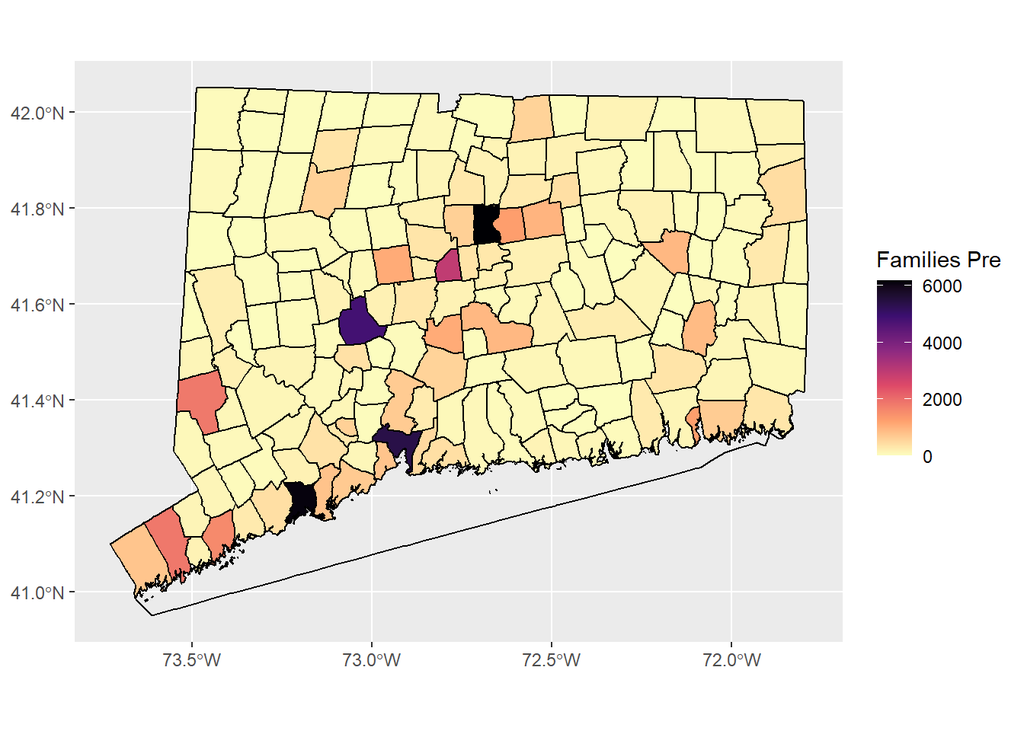

```r
# map families by town pre-move
ggplot() + geom_sf(data = towns_moved, aes(fill = `Families Pre`)) +
  scale_fill_viridis_c(option = "magma", direction = -1) + geom_sf(data = town_lines)
```

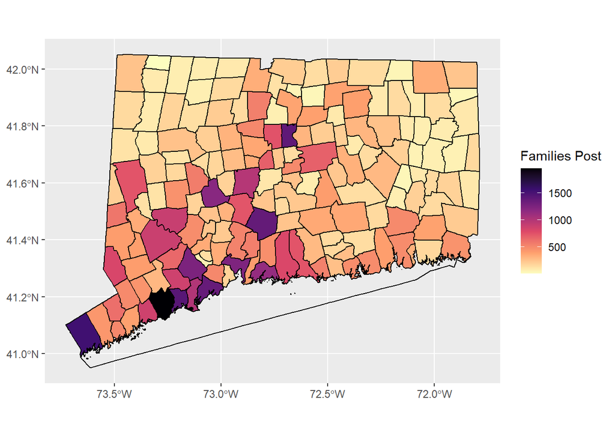

```r
# map families by town post-move
ggplot() + geom_sf(data = towns_moved, aes(fill = `Families Post`)) +
  scale_fill_viridis_c(option = "magma", direction = -1) + geom_sf(data = town_lines)
```

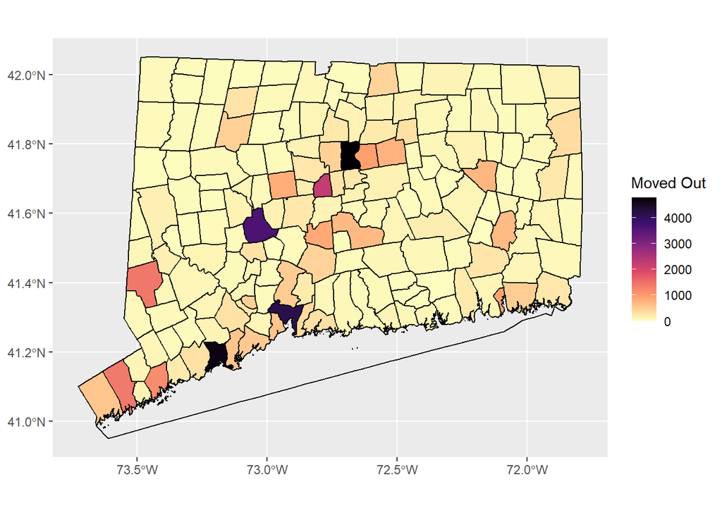

```r
# map families moving out or staying
ggplot() + geom_sf(data = towns_moved, aes(fill = `Moved Out`)) +
  scale_fill_viridis_c(option = "magma", direction = -1) + geom_sf(data = town_lines)
```

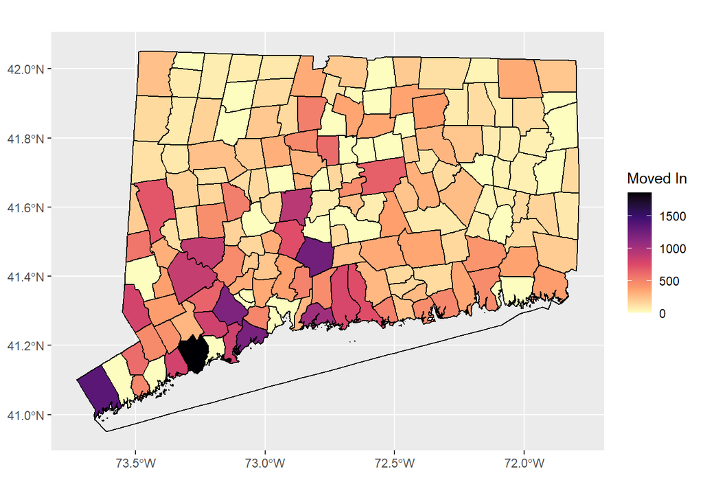

```r
# map families moving in or staying
ggplot() + geom_sf(data = towns_moved, aes(fill = `Moved In`)) +
  scale_fill_viridis_c(option = "magma", direction = -1) + geom_sf(data = town_lines)
```

```r
# assign baseline incidence by town
ischemic_town <- town_polygon %>%
  select(`CNTY_NAME`, `TOWN_NAME`) %>%
  left_join(ischemic, by = "CNTY_NAME") %>%
  group_by(`TOWN_NAME`) %>%
  summarize(`IHD` = mean(`Crude.Rate`))

# assign dose-response relationships / health impact functions
## ischemic heart disease and PM2.5 - PLACEHOLDER, MADE UP
dr_pm_ischemic <- 0.08 # 8% decrease in IHD mortality per 10 ug/m3 decrease in PM2.5

## ischemic heart disease and O3
## others


# list towns post-move by family moved (one row per family moved)
moved_in_to <- rep(pop_town$TOWN_NAME, times = pop_town$`Moved In`)

# combine towns pre-move by family and towns post-move by family to assign pre- and post- location to each family
town_moved_pre_post <- data.frame(moved_out_from, moved_in_to) %>%
## join pre-move exposure
  rename(`TOWN_NAME` = `moved_out_from`) %>%
  left_join(pm_town, by = "TOWN_NAME") %>%
  ## join pre-move incidence rates
  left_join(ischemic_town, by = "TOWN_NAME") %>%
## join post-move exposure
  select(`moved_out_from` = `TOWN_NAME`, `TOWN_NAME` = `moved_in_to`, `PM2.5 Pre` = `Average PM2.5 (ug/m3)`, `IHD Pre` = `IHD`) %>%
  left_join(pm_town, by = "TOWN_NAME") %>%
  select(`moved_out_from`, `moved_in_to` = `TOWN_NAME`, `PM2.5 Pre`, `PM2.5 Post` = `Average PM2.5 (ug/m3)`, `IHD Pre` = `IHD Pre`) %>%
## calculate change in exposure
  mutate(`Change in PM2.5 (ug/m3)` = `PM2.5 Post` - `PM2.5 Pre`) %>%
  mutate(`% Change in IHD` = `Change in PM2.5 (ug/m3)`/10*dr_pm_ischemic) %>%
  mutate(`IHD Post` = `IHD Pre`*(1 +`% Change in IHD`)) %>%
  mutate(`IHD Post - Pre` = `IHD Post` - `IHD Pre`)

head(town_moved_pre_post)
```

|  | moved_out_from | moved_in_to | PM2.5 Pre | PM2.5 Post | IHD Pre | Change in PM2.5 (ug/m3) | % Change in IHD | IHD Post | IHD Post - Pre |
| --- | --- | --- | --- | --- | --- | --- | --- | --- | --- |
| 1 | Bridgeport | Andover | 19.52384 | 16.057 | 94.134 | -3.4668421 | -0.027734737 | 91.52322 | -2.6107817 |
| 2 | East Haven | Andover | 17.82857 | 16.057 | 97.806 | -1.7715714 | -0.014172571 | 96.41984 | -1.3861625 |
| 3 | Killingly | Andover | 15.73067 | 16.057 | 132.726 | 0.3263333 | 0.002610667 | 133.07250 | 0.3465033 |
| 4 | Ledyard | Andover | 15.09450 | 16.057 | 121.038 | 0.9625000 | 0.007700000 | 121.96999 | 0.9319926 |
| 5 | Hartford | Andover | 17.20960 | 16.057 | 104.629 | -1.1526000 | -0.009220800 | 103.66424 | -0.9647631 |
| 6 | Windsor | Andover | 16.91143 | 16.057 | 104.629 | -0.8544286 | -0.006835429 | 103.91382 | -0.7151841 |

```r
# add total cases prevented - rate per 100,000 people, each family assumed to have 4 individuals
sum(town_moved_pre_post$`IHD Post - Pre`)/100000*4
```

```
## [1] 0.03025852
```

**To-do/to-figure-out** * Should we randomize family size? Or use average family size specific to each town? * Population of interest - use 80% AMI (HUD definition but may require calculations), families in poverty (currently - ACS variable B17013_002), or rent burden (can use ACS variables B25095_006 et al. and add up rent burdened estimates across income groups)? * Estimating change in incidence - do we need to know start and end town for each individual/family unit (I’m assuming yes)? Or is there a way to analyze just looking at pre/post distributions? * Better way to aggregate tracts into towns (also need to check if 2019 tracts = 2010 tracts)? + Best way to deal with tracts containing/contained in multiple townships? Specifically three tracts with 0 families, should I split into multiple observations so pollution estimate can be input into town average? * Mean vs median to average pollution exposure across census tracts when aggregating to towns? * Identify/quantify cause-specific mortality endpoints and dose-response relationships (refer to BenMAP) * Verify - we only need to simulate movement and calculate exposure/incidence changes for this specific population right? Since others not in this population are presumed to stay in place? Is it worth adding random movement of all CT residents? * Percent affordable based on total assisted units / total units - total assisted currently includes government assisted, tenant rental assistance, SF CHFA USDA mortgages, and deed restricted units - good definition? * Add inverse distance weighting penalty to movement simulation * Crude vs. age-adjusted (or otherwise adjusted) incidence rates? * Where to get incidence rates specific to population?